# Quantifying the Visual Mechanisms Underlying the Rod-and-Frame Illusion

Ernestine Brannon

## Analysis

```r
all_task<- cbind(s2r_abs,s2v_abs) %>%
  select(sid, frame_effect_r, frame_effect_v, frame_size)


p_df<- perception_abs %>%
  ungroup() %>%
  select(magnitude, sid) %>%
  rename(sub_1 =sid)

all_task<- cbind(all_task,p_df)

all_task<- all_task %>%
  select(-sub_1)

all_task<-all_task %>%
  rename(vv= frame_effect_v,
         oc = frame_effect_r,
         perc = magnitude)
```

### Perception Task: RFI

To determine the change in PSE as a function of frame size, we subtracted the PSE for counterclockwise trials from clockwise trials, and then divided that by half.

A negative value indicates that participants PSEs are being biased in the opposite direction of the tilt of the frame.

(#tab:percept summary stat table)

*Perception Task*

| Frame Size | Mean | Median | SD | Min | Max |
| --- | --- | --- | --- | --- | --- |
| Small | 2.11 | 2.00 | 1.15 | -0.27 | 6.35 |
| Medium | 1.91 | 1.71 | 1.12 | 0.15 | 6.68 |
| Large | 1.71 | 1.45 | 1.02 | -0.06 | 4.77 |
| Extra Large | 1.55 | 1.33 | 0.99 | -0.50 | 5.80 |

| Perception Task: RFI frame_size | Perception Task: RFI estimate | Perception Task: RFI statistic | Perception Task: RFI p | Perception Task: RFI parameter | Perception Task: RFI Method | Perception Task: RFI Alternative | Perception Task: RFI 95% CI |
| --- | --- | --- | --- | --- | --- | --- | --- |
| 175 | 2.11 | 16.44 | < .001*** | 79.00 | One Sample t-test | two.sided | [1.85, 2.37] |
| 410 | 1.91 | 15.27 | < .001*** | 79.00 | One Sample t-test | two.sided | [1.66, 2.16] |
| 645 | 1.71 | 14.97 | < .001*** | 79.00 | One Sample t-test | two.sided | [1.48, 1.93] |
| 880 | 1.55 | 14.03 | < .001*** | 79.00 | One Sample t-test | two.sided | [1.33, 1.77] |

```r
p_mag_anova<- aov(frame_effect_perception ~frame_size, data =perception)
summary(p_mag_anova)
```

```
##              Df Sum Sq Mean Sq F value Pr(>F)
## frame_size    3   14.3   4.759   4.154 0.0066 **
## Residuals   316  362.0   1.146
## ---
## Signif. codes:  0 '***' 0.001 '**' 0.01 '*' 0.05 '.' 0.1 ' ' 1
```

```r
tukey_p<-tukey_hsd(p_mag_anova)
apa_table(tukey_p)
```

(#tab:perc aov frame size effect)

| term | group1 | group2 | null.value | estimate | conf.low | conf.high | p.adj | p.adj.signif |
| --- | --- | --- | --- | --- | --- | --- | --- | --- |
| frame_size | 175 | 410 | 0.00 | -0.20 | -0.64 | 0.24 | 0.63 | ns |
| frame_size | 175 | 645 | 0.00 | -0.40 | -0.84 | 0.03 | 0.08 | ns |
| frame_size | 175 | 880 | 0.00 | -0.56 | -1.00 | -0.12 | 0.01 | ** |
| frame_size | 410 | 645 | 0.00 | -0.20 | -0.64 | 0.24 | 0.64 | ns |
| frame_size | 410 | 880 | 0.00 | -0.36 | -0.80 | 0.08 | 0.15 | ns |
| frame_size | 645 | 880 | 0.00 | -0.16 | -0.60 | 0.28 | 0.78 | ns |

*The results between the table and graph are inconsistent due to different tests being used. I am unsure whether I need to use the Tukey HSD test ( shown in the table above) or if a Bonferroni correction is more appropriate (used in the violin graph below).*

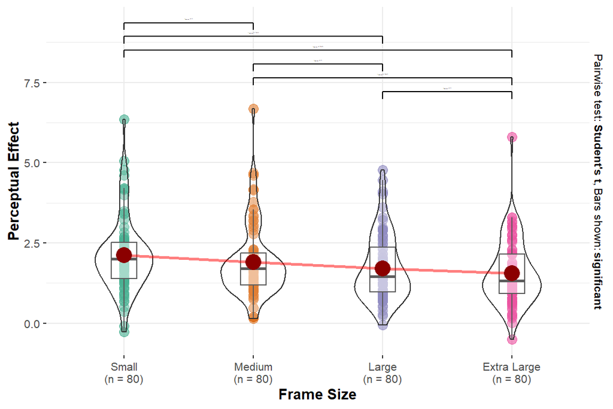

### Saccade-to-Vertical Task: Visuovestibular Effect

The effect of the frames was quantified by subtracting the mean errors for the counterclockwise-tilted frames from those of the clockwise-tilted frames then halving this value to get a measure of the average effect of a single frame (negative values indicated eye movements that deviated in the direction opposite the tilt of the frame).

(#tab:s2v summary stat table)

*Saccade-to-Vertical Task*

| Frame Size | Mean | Median | SD | Min | Max |
| --- | --- | --- | --- | --- | --- |
| Small | 1.47 | 1.31 | 1.63 | -2.77 | 8.74 |
| Medium | 1.23 | 1.01 | 1.75 | -1.84 | 8.34 |
| Large | 1.14 | 1.04 | 1.35 | -1.63 | 5.91 |
| Extra Large | 1.04 | 0.88 | 1.51 | -2.10 | 8.97 |

```r
s2v_ttest_df<-saccade_to_vert_magnitude %>% group_by(FRAME_SIZE_VAL) %>% do(tidy(t.test(.$frame_effect_v)))
nice_table(s2v_ttest_df)
```

| FRAME_SIZE_VAL | estimate | statistic | p | parameter | Method | Alternative | 95% CI |
| --- | --- | --- | --- | --- | --- | --- | --- |
| 175 | 1.47 | 8.04 | < .001*** | 79.00 | One Sample t-test | two.sided | [1.11, 1.83] |
| 410 | 1.23 | 6.29 | < .001*** | 79.00 | One Sample t-test | two.sided | [0.84, 1.62] |
| 645 | 1.14 | 7.55 | < .001*** | 79.00 | One Sample t-test | two.sided | [0.84, 1.44] |
| 880 | 1.04 | 6.16 | < .001*** | 79.00 | One Sample t-test | two.sided | [0.70, 1.37] |

```r
vv_mag_anova<- aov(frame_effect_v~FRAME_SIZE_VAL, data =saccade_to_vert_magnitude)
#summary(vv_mag_anova)
tukey_vv<-tukey_hsd(vv_mag_anova)
apa_table(tukey_vv)
```

(#tab:s2v aov frame size effect)

| term | group1 | group2 | null.value | estimate | conf.low | conf.high | p.adj | p.adj.signif |
| --- | --- | --- | --- | --- | --- | --- | --- | --- |
| FRAME_SIZE_VAL | 175 | 410 | 0.00 | -0.24 | -0.88 | 0.40 | 0.77 | ns |
| FRAME_SIZE_VAL | 175 | 645 | 0.00 | -0.33 | -0.97 | 0.31 | 0.56 | ns |
| FRAME_SIZE_VAL | 175 | 880 | 0.00 | -0.43 | -1.07 | 0.21 | 0.31 | ns |
| FRAME_SIZE_VAL | 410 | 645 | 0.00 | -0.09 | -0.73 | 0.55 | 0.98 | ns |
| FRAME_SIZE_VAL | 410 | 880 | 0.00 | -0.19 | -0.83 | 0.45 | 0.87 | ns |
| FRAME_SIZE_VAL | 645 | 880 | 0.00 | -0.10 | -0.75 | 0.54 | 0.98 | ns |

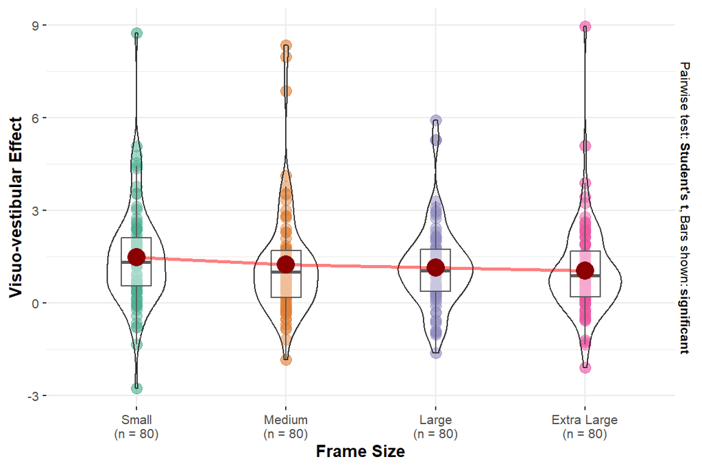

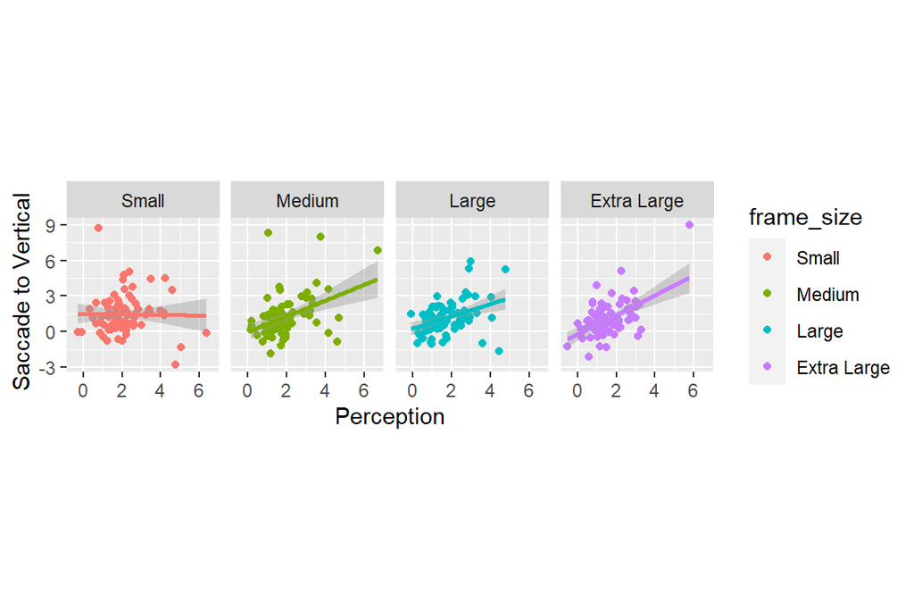

### Saccade to Rod : Orientation Contrast Effect

The effect of the frames was quantified by subtracting the mean errors for the counterclockwise-tilted frames from those of the clockwise-tilted frames then halving this value to get a measure of the average effect of a single frame (negative values indicated eye movements that deviated in the direction opposite the tilt of the frame).

(#tab:s2r summary stat table)

*Saccade-to-Rod Task: Orientation Contrast Effect*

| Frame Size | Mean | Median | SD | Min | Max |
| --- | --- | --- | --- | --- | --- |
| Small | -1.61 | -1.50 | 1.44 | -6.47 | 4.51 |
| Medium | -0.88 | -0.99 | 1.24 | -4.38 | 2.39 |
| Large | -0.62 | -0.58 | 1.35 | -4.01 | 4.02 |
| Extra Large | -0.76 | -0.70 | 1.14 | -4.76 | 2.57 |

| FRAME_SIZE_VAL | estimate | statistic | p | parameter | Method | Alternative | 95% CI |
| --- | --- | --- | --- | --- | --- | --- | --- |
| 175 | -1.61 | -9.98 | < .001*** | 79.00 | One Sample t-test | two.sided | [-1.93, -1.29] |
| 410 | -0.88 | -6.36 | < .001*** | 79.00 | One Sample t-test | two.sided | [-1.15, -0.60] |
| 645 | -0.62 | -4.09 | < .001*** | 79.00 | One Sample t-test | two.sided | [-0.92, -0.32] |
| 880 | -0.76 | -5.94 | < .001*** | 79.00 | One Sample t-test | two.sided | [-1.01, -0.50] |

```r
# oc_mag_anova<- aov(frame_effect_r~FRAME_SIZE_VAL, data =saccade_to_rod_magnitude)
# summary(oc_mag_anova)
# tukey_oc<-tukey_hsd(oc_mag_anova)
# apa_table(tukey_oc)
```

[output not shown]

(#tab:s2r within graph)

term

group1

group2

null.value

estimate

conf.low

conf.high

p.adj

p.adj.signif

FRAME_SIZE_VAL

Small

Medium

0.00

0.73

0.20

1.26

0.00

FRAME_SIZE_VAL

Small

Large

0.00

0.99

0.46

1.52

0.00

FRAME_SIZE_VAL

Small

Extra Large

0.00

0.85

0.32

1.38

0.00

***

FRAME_SIZE_VAL

Medium

Large

0.00

0.26

-0.27

0.79

0.58

ns

FRAME_SIZE_VAL

Medium

Extra Large

0.00

0.12

-0.41

0.65

0.94

ns

FRAME_SIZE_VAL

Large

Extra Large

0.00

-0.14

-0.67

0.39

0.90

ns

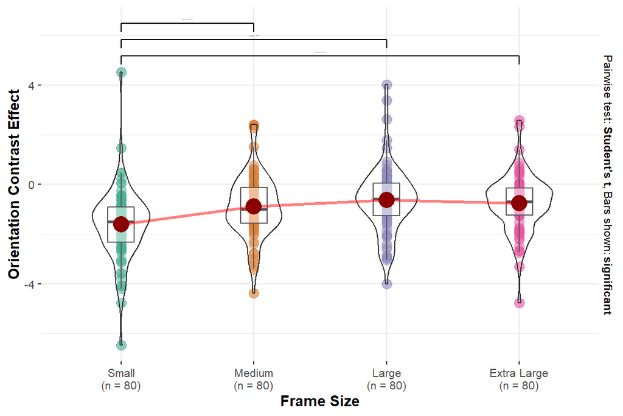

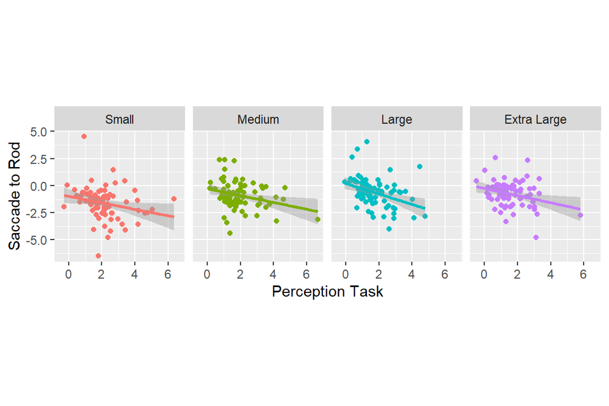

### Combined Saccades and Perception Task Comparison

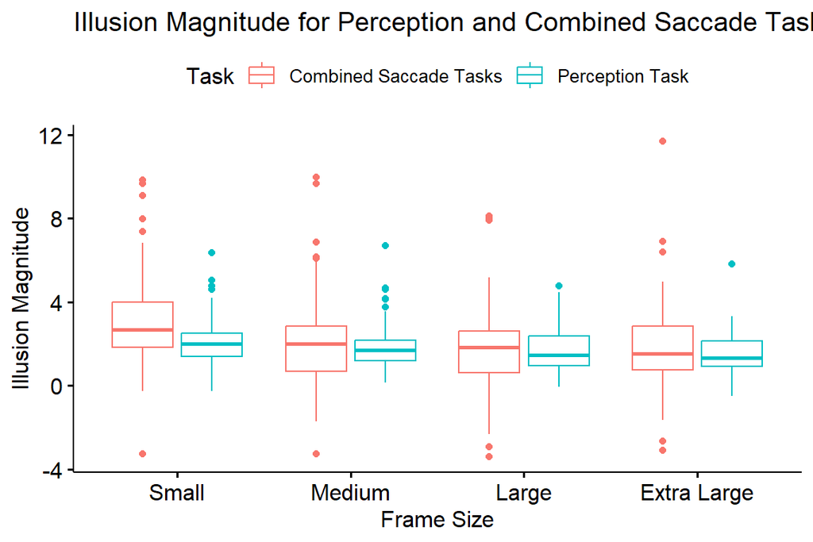

```
## Effect sizes were labelled following Funder's (2019) recommendations.
##
## The Pearson's product-moment correlation between across_frames$perception and
## across_frames$combined_saccade is positive, statistically significant, and very
## large (r = 0.43, 95% CI [0.33, 0.51], t(318) = 8.45, p < .001)
```

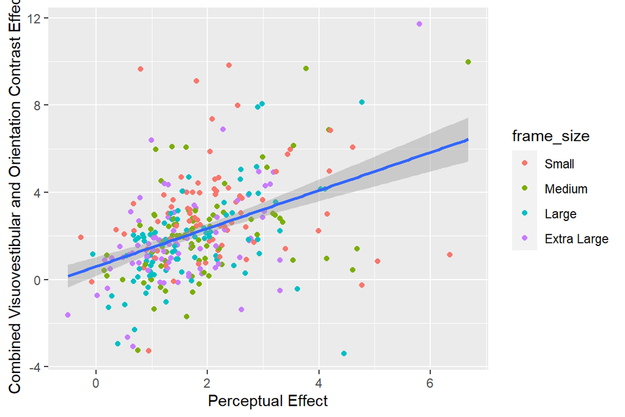

```
## Effect sizes were labelled following Funder's (2019) recommendations.
##
## The Pearson's product-moment correlation between across_frames$perception and
## across_frames$combined_saccade is positive, statistically significant, and very
## large (r = 0.43, 95% CI [0.33, 0.51], t(318) = 8.45, p < .001)
```

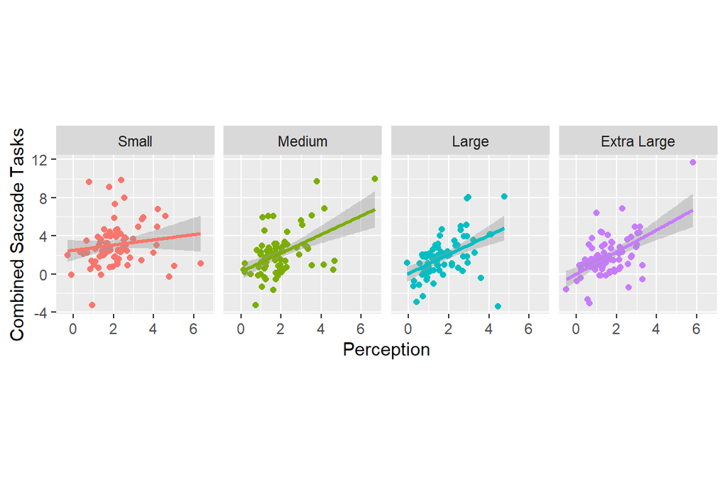

**Perception and Saccade-to-Vertical**

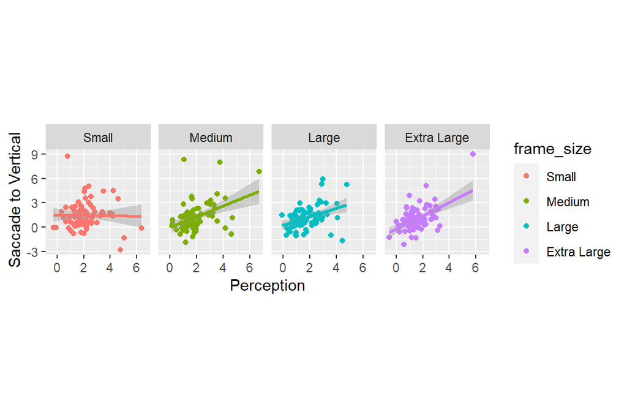

**Perception and Saccade-to-Rod**

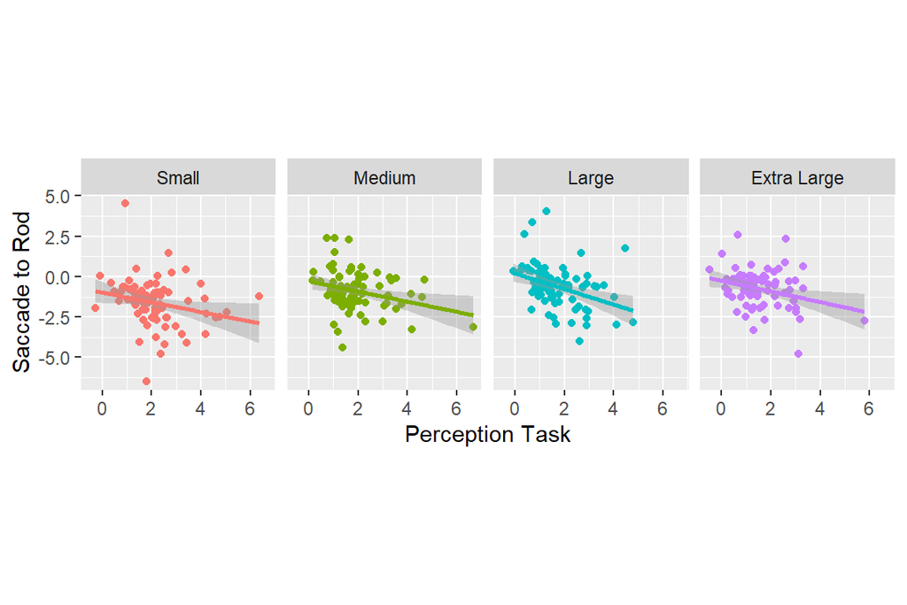

### Model Comparison

For each frame size a hierarchical design was employed using two models: 1) model 1 predicted the overall RFI magnitude (measured by the perception task) from the visuovestibular effect (measured by the saccade-to-vertical task) and 2) model 2 predicted the overall RFI magnitude from visuovestibular effect and the orientation contrast effect (measured by the saccade-to-rod task).

- **Small Frame**

```
##
## Call:
## lm(formula = perc ~ vv, data = df_small)
##
## Residuals:
##     Min      1Q  Median      3Q     Max
## -2.4004 -0.7165 -0.1283  0.4315  4.2230
##
## Coefficients:
##             Estimate Std. Error t value Pr(>|t|)
## (Intercept)  2.12753    0.17419  12.214   <2e-16 ***
## vv          -0.01199    0.07954  -0.151    0.881
## ---
## Signif. codes:  0 '***' 0.001 '**' 0.01 '*' 0.05 '.' 0.1 ' ' 1
##
## Residual standard error: 1.155 on 78 degrees of freedom
## Multiple R-squared:  0.0002913,  Adjusted R-squared:  -0.01253
## F-statistic: 0.02273 on 1 and 78 DF,  p-value: 0.8805
```

```
##
## Call:
## lm(formula = perc ~ vv + oc, data = df_small)
##
## Residuals:
##     Min      1Q  Median      3Q     Max
## -2.4789 -0.6643 -0.1876  0.3187  4.2826
##
## Coefficients:
##             Estimate Std. Error t value Pr(>|t|)
## (Intercept)  1.83034    0.21902   8.357 2.08e-12 ***
## vv          -0.01792    0.07779  -0.230   0.8184
## oc          -0.19003    0.08810  -2.157   0.0341 *
## ---
## Signif. codes:  0 '***' 0.001 '**' 0.01 '*' 0.05 '.' 0.1 ' ' 1
##
## Residual standard error: 1.129 on 77 degrees of freedom
## Multiple R-squared:  0.05726,    Adjusted R-squared:  0.03277
## F-statistic: 2.338 on 2 and 77 DF,  p-value: 0.1033
```

```
## [1] 0.05696534
```

```
## Analysis of Variance Table
##
## Model 1: perc ~ vv
## Model 2: perc ~ vv + oc
##   Res.Df    RSS Df Sum of Sq      F  Pr(>F)
## 1     78 104.12
## 2     77  98.19  1    5.9331 4.6527 0.03412 *
## ---
## Signif. codes:  0 '***' 0.001 '**' 0.01 '*' 0.05 '.' 0.1 ' ' 1
```

- **Medium Frame**

```
## [1] 0.0631005
```

```
## Analysis of Variance Table
##
## Model 1: perc ~ vv
## Model 2: perc ~ vv + oc
##   Res.Df    RSS Df Sum of Sq      F  Pr(>F)
## 1     78 80.926
## 2     77 74.703  1    6.2227 6.4141 0.01336 *
## ---
## Signif. codes:  0 '***' 0.001 '**' 0.01 '*' 0.05 '.' 0.1 ' ' 1
```

- **Large Frame**

```
## [1] 0.08649254
```

```
## Analysis of Variance Table
##
## Model 1: perc ~ vv
## Model 2: perc ~ vv + oc
##   Res.Df    RSS Df Sum of Sq      F   Pr(>F)
## 1     78 69.863
## 2     77 62.747  1    7.1162 8.7326 0.004146 **
## ---
## Signif. codes:  0 '***' 0.001 '**' 0.01 '*' 0.05 '.' 0.1 ' ' 1
```

- **Extra Large Frame**

```
## [1] 0.02668074
```

```
## Analysis of Variance Table
##
## Model 1: perc ~ vv
## Model 2: perc ~ vv + oc
##   Res.Df    RSS Df Sum of Sq      F  Pr(>F)
## 1     78 54.640
## 2     77 52.586  1    2.0533 3.0066 0.08693 .
## ---
## Signif. codes:  0 '***' 0.001 '**' 0.01 '*' 0.05 '.' 0.1 ' ' 1
```